# project week 2

Mateo Córdoba Toro

2/7/2020

# Project Assignment 1 - Week 2

## Mateo Córdoba Toro

### Loading Data

The data was downloaded in the folder containing the project in R. The data was loaded with the name “Data”.

```r
data <- read.csv("activity.csv",sep=",",header = TRUE)
```

### Libraries

To carry out the work, 4 libraries were used:

- ggplot2 Generate charts
- dplyr Data Management
- lubridate date handling
- chron Date management (identify weekends)

```r
library(ggplot2)
library(dplyr)
library(lubridate)
library(chron)
```

## What is mean total number of steps taken per day?

The number of steps per day is calculated by grouping the data by date and then adding the steps.

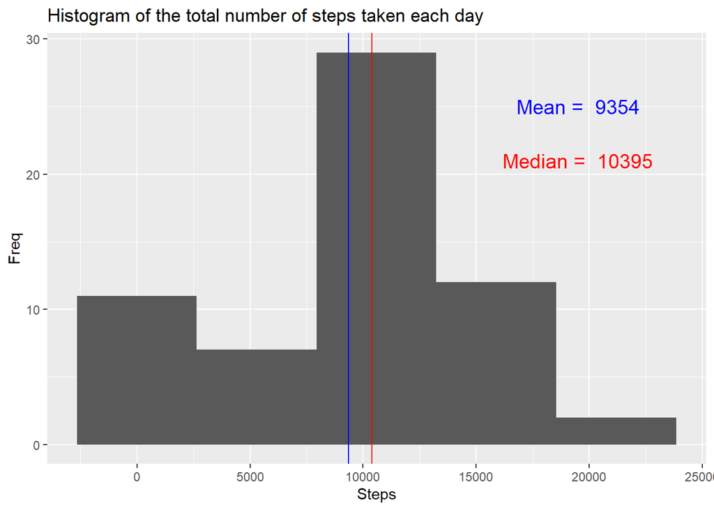

```r
df <- data %>% group_by(date) %>% summarise(suma  = sum(steps, na.rm = TRUE))

# Histogram
qplot(suma,data=df,geom = "histogram", bins=5)+
  labs(title = "Histogram of the total number of steps taken each day",
       x     = "Steps",
       y     = "Freq")+
  geom_vline(xintercept = mean(df$suma), colour="blue", linetype = "solid") +
  geom_vline(xintercept = median(df$suma), colour="red", linetype = "solid")  +
  annotate("text", label = paste("Mean = ",trunc(mean(df$suma)), sep = " "),
           x = 19500, y = 25, size = 5, colour = "blue") +
  annotate("text", label = paste("Median = ",median(df$suma), sep = " "),
           x = 19500, y = 21, size = 5, colour = "red")
```

```r
dev.copy(png, "hist1.png",width=480, height=480)
```

```r
dev.off()
```

### Mean and median

```r
summary(df$suma)
```

```
##    Min. 1st Qu.  Median    Mean 3rd Qu.    Max.
##       0    6778   10395    9354   12811   21194
```

## What is the average daily activity pattern?

The data are grouped by interval and later the average of the steps taken by interval is estimated to later graph the generated time series.

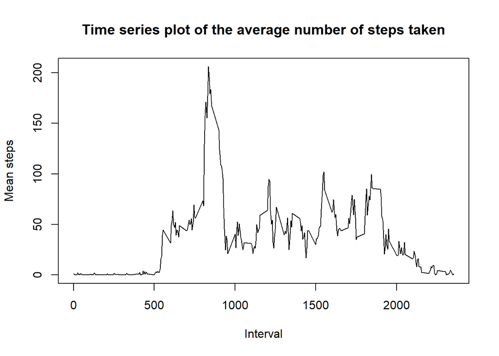

```r
df_interval <- data %>% group_by(interval) %>% summarise( mean = mean(steps, na.rm = TRUE))

plot(df_interval$interval,df_interval$mean, type = "l",
     main = "Time series plot of the average number of steps taken",
     xlab = "Interval",
     ylab = "Mean steps")
```

```r
dev.copy(png, "timeseries.png",width=480, height=480)
```

```r
dev.off()
```

## Imputing missing values

### Calulate the the total number of missing values

The total missing values in the dataset

```r
table(is.na(data$steps))[2]
```

```
## TRUE
## 2304
```

### Imputing Strategy

The imputation strategy is to fill in the missing values with the average of the total steps.

```r
data[is.na(data$steps),1] <- mean(data$steps, na.rm = TRUE)
```

### Histogram

When the missing values are replaced by the mean of the total data, it is observed how the distribution of the histogram coincides towards the mean. Behavior that is not surprising since it is for this value that the missing values are being replaced.

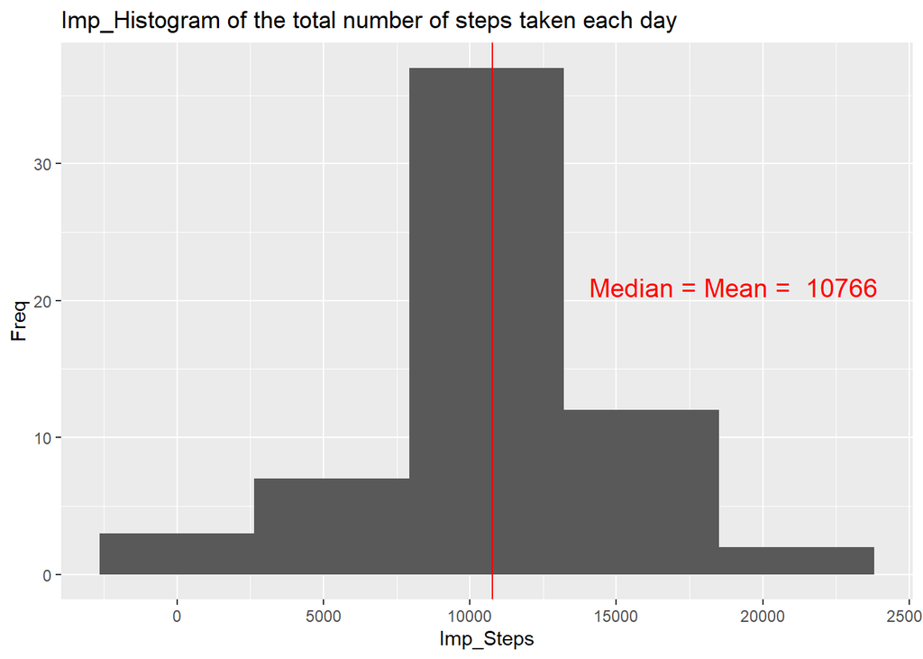

```r
df_imp  <- data %>% group_by(date) %>% summarise(suma  = sum(steps, na.rm = TRUE))
qplot(suma,data=df_imp,geom = "histogram", bins=5)+
  labs(title = "Imp_Histogram of the total number of steps taken each day",
       x     = "Imp_Steps",
       y     = "Freq")+
  geom_vline(xintercept = mean(df_imp$suma), colour="blue", linetype = "solid") +
  geom_vline(xintercept = median(df_imp$suma), colour="red", linetype = "solid")  +
  annotate("text", label = paste("Median = Mean = ",trunc(median(df_imp$suma)), sep = " "),
           x = 19000, y = 21, size = 5, colour = "red")
```

```r
dev.copy(png, "hist2.png",width=480, height=480)
```

```r
dev.off()
```

### Mean and median

```r
summary(df_imp$suma)
```

```
##    Min. 1st Qu.  Median    Mean 3rd Qu.    Max.
##      41    9819   10766   10766   12811   21194
```

## Are there differences in activity patterns between weekdays and weekends?

A new “Weekend” variable was created that classifies between days of the week and weekends.

```r
data <- data %>% mutate( Weekend = as.factor(case_when(is.weekend(data$date) == FALSE ~ "WEEKDAY",
                                               is.weekend(data$date) == TRUE  ~ "WEEKEND")))
```

We made the graph taking the x-axis as the intervals and the axis and the mean of the steps that were calculated later.

A slight rise is observed in the middle of the steps taken on weekends.

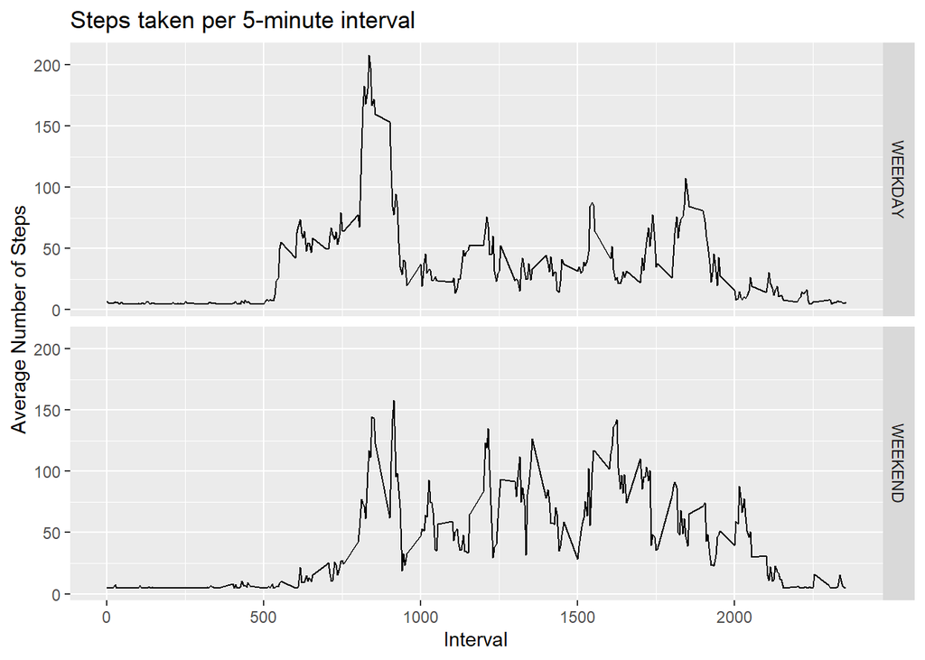

```r
data_1 <- aggregate(steps ~ interval + Weekend, data, mean)

ggplot(data_1, aes(interval, steps))+
  geom_line()+
  facet_grid(Weekend~.)+
  labs(title = "Steps taken per 5-minute interval",
       x = "Interval",
       y = " Average Number of Steps")
```

```r
dev.copy(png, "timeseries2.png",width=480, height=480)
```

```r
dev.off()
```